# Klasyfikacja dokumentów cz.1

Bogna Zacny

zima 2019/2020

## Przygotowanie środowiska

Przydatne pakiety

```
install.packages(c("dplyr", "tidyr", "ggplot2", "kernlab", "caret", "class", "e1071"))

library("dplyr")
library("tidyr")
library("ggplot2")
library("kernlab")
library("caret")
library("class")
library("e1071")
data("spam")
```

Przestrzeń robocza

```
setwd("C:/Users/UE/Documents/R")
```

## Klasyfikacja z wykorzystaniem algorytmu `k-nn (k najbliższych sąsiadów)`

### Analiza wstępna

Zbiór danych

```r
dane <- data.frame(hello = c(1,1,2,1,1,0,1,2,1,3),
                   business = c(0,1,3,0,1,2,0,1,2,3),
                   replica = c(3,2,1,0,0,0,1,0,3,0),
                   mail = c("spam","spam","ham","ham","ham","ham","spam","ham","spam","ham"))
dane
```

```
##    hello business replica mail
## 1      1        0       3 spam
## 2      1        1       2 spam
## 3      2        3       1  ham
## 4      1        0       0  ham
## 5      1        1       0  ham
## 6      0        2       0  ham
## 7      1        0       1 spam
## 8      2        1       0  ham
## 9      1        2       3 spam
## 10     3        3       0  ham
```

Przeglądając zbiór danych możemy zauważyć, że:

```r
table(dane$mail)
```

```
##
##  ham spam
##    6    4
```

Wizualizacja 2d

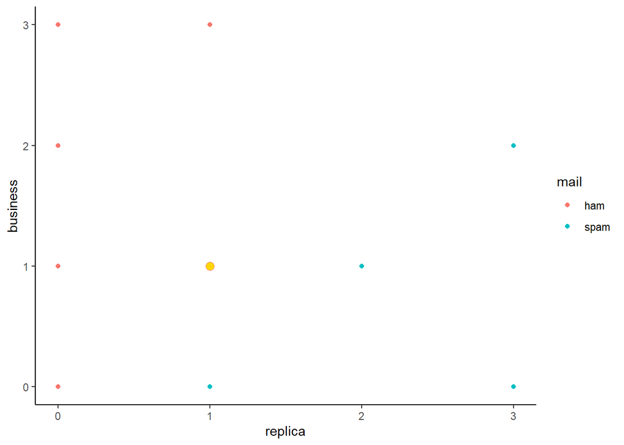

```r
dane %>%
  select(replica, business, mail) %>%
  ggplot(aes(x = replica, y = business, color = mail)) +
  geom_point() +
  geom_point(x = 1, y = 1, fill = "gold", shape = 21, size = 3, show.legend = F) +
  theme_classic()
```

### Analiza właściwa

#### budowa klasyfikatora

W bibliotece *`class`* znajduje się funkcja `knn()`, która dokona za nas przydzielenia nowym obiektom `test`, klas wyznaczonych na podstawie zbioru treningowego `train`.

```r
modelSpamKnn <- knn(train = dane[,c(-1, -4)],
              test = data.frame(business = 1,  replica = 1),
              cl = dane[,4],
              k = 3)
modelSpamKnn
```

```
## [1] ham
## Levels: ham spam
```

```r
modelSpamKnn <- knn(train = dane[,c(-1, -4)],
              test = data.frame(business = 2,  replica = 1),
              cl = dane[,4],
              k = 3)
modelSpamKnn
```

```
## [1] ham
## Levels: ham spam
```

dla całego zbioru

```r
modelSpamKnn <- knn(train = dane[,-4],
              test = dane[,-4],
              cl = dane[,4],
              k = 3)
modelSpamKnn
```

```
##  [1] spam spam ham  ham  ham  ham  spam ham  spam ham
## Levels: ham spam
```

#### ocena klasyfikatora

```r
confusionMatrix(modelSpamKnn, dane$mail)
```

```
## Confusion Matrix and Statistics
##
##           Reference
## Prediction ham spam
##       ham    6    0
##       spam   0    4
##
##                Accuracy : 1
##                  95% CI : (0.6915, 1)
##     No Information Rate : 0.6
##     P-Value [Acc > NIR] : 0.006047
##
##                   Kappa : 1
##
##  Mcnemar's Test P-Value : NA
##
##             Sensitivity : 1.0
##             Specificity : 1.0
##          Pos Pred Value : 1.0
##          Neg Pred Value : 1.0
##              Prevalence : 0.6
##          Detection Rate : 0.6
##    Detection Prevalence : 0.6
##       Balanced Accuracy : 1.0
##
##        'Positive' Class : ham
##
```

“Ręczne” wyznaczenie trafności klasyfikatora

```r
mean(modelSpamKnn == dane$mail)
```

```
## [1] 1
```

## Klasyfikacja z wykorzystaniem algorytmu `Naiwnego klasyfikatora bayesowskiego`

### Analiza wstępna

Zbiór danych

```r
dane <- data.frame(hello = c(1,1,2,1,1,0,1,2,1,3),
                   business = c(0,1,3,0,1,2,0,1,2,3),
                   replica = c(3,2,1,0,0,0,1,0,3,0),
                   mail = c("spam","spam","ham","ham","ham","ham","spam","ham","spam","ham"))
dane
```

```
##    hello business replica mail
## 1      1        0       3 spam
## 2      1        1       2 spam
## 3      2        3       1  ham
## 4      1        0       0  ham
## 5      1        1       0  ham
## 6      0        2       0  ham
## 7      1        0       1 spam
## 8      2        1       0  ham
## 9      1        2       3 spam
## 10     3        3       0  ham
```

Przeglądając zbiór danych możemy zauważyć, że:

```r
table(dane$mail)
```

```
##
##  ham spam
##    6    4
```

```r
dane %>%
  group_by(mail) %>%
  summarise_all(funs(mean(.), sd(.))) %>%
  select(mail, starts_with("hello"), starts_with("business"), starts_with("replica"))
```

```
## # A tibble: 2 x 7
##   mail  hello_mean hello_sd business_mean business_sd replica_mean
##   <fct>      <dbl>    <dbl>         <dbl>       <dbl>        <dbl>
## 1 ham          1.5     1.05          1.67       1.21         0.167
## 2 spam         1       0             0.75       0.957        2.25
## # ... with 1 more variable: replica_sd <dbl>
```

Wizualizacja

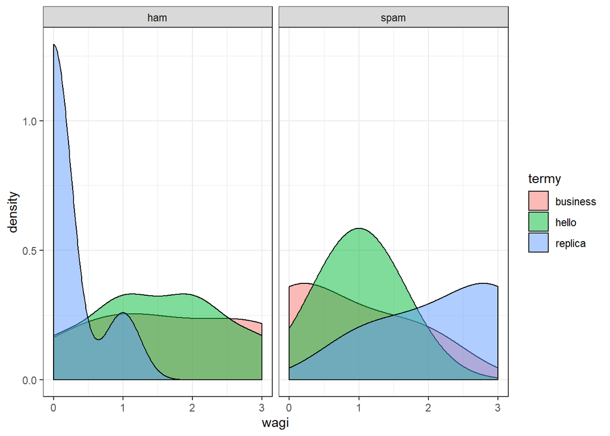

```r
dane %>%
  gather(termy, wagi, -mail) %>%
  ggplot(aes(x = wagi, fill = termy)) +
  geom_density(alpha = 0.5) +
  facet_wrap(~ mail) +
  theme_bw()
```

### Analiza właściwa

#### budowa klasyfikatora

Wykorzystując bibliotekę *`e1071`* przygotuj model pozwalający na określenie prawdopodobieństwa, że mail będzie spamem, pod warunkiem wystąpienia w treści maila wskazanych termów. Funkcja `naiveBayes()` stworzy naiwny klasyfikator bayesowski.

```r
library("e1071")
modelSpamBay <- naiveBayes(mail ~ ., data = dane)
modelSpamBay
```

```
##
## Naive Bayes Classifier for Discrete Predictors
##
## Call:
## naiveBayes.default(x = X, y = Y, laplace = laplace)
##
## A-priori probabilities:
## Y
##  ham spam
##  0.6  0.4
##
## Conditional probabilities:
##       hello
## Y      [,1]     [,2]
##   ham   1.5 1.048809
##   spam  1.0 0.000000
##
##       business
## Y          [,1]      [,2]
##   ham  1.666667 1.2110601
##   spam 0.750000 0.9574271
##
##       replica
## Y           [,1]      [,2]
##   ham  0.1666667 0.4082483
##   spam 2.2500000 0.9574271
```

Wyświetlenie prawdopodobieństwa `a posteriori` wraz ze wskazaniem przewidywanej klasy

```r
data.frame(round(predict(modelSpamBay, dane[, -4], type = "raw"), 4),
           Predykcja = predict(modelSpamBay, dane[, -4], type = "class"),
           Empiryczne = dane[, 4])
```

```
##       ham   spam Predykcja Empiryczne
## 1  0.0000 1.0000      spam       spam
## 2  0.0000 1.0000      spam       spam
## 3  0.9996 0.0004       ham        ham
## 4  0.0178 0.9822      spam        ham
## 5  0.0297 0.9703      spam        ham
## 6  0.9999 0.0001       ham        ham
## 7  0.0004 0.9996      spam       spam
## 8  0.9999 0.0001       ham        ham
## 9  0.0000 1.0000      spam       spam
## 10 1.0000 0.0000       ham        ham
```

#### ocena klasyfikatora

```r
spam_przewid <- predict(modelSpamBay, dane[, -4])
confusionMatrix(spam_przewid, dane$mail)
```

```
## Confusion Matrix and Statistics
##
##           Reference
## Prediction ham spam
##       ham    4    0
##       spam   2    4
##
##                Accuracy : 0.8
##                  95% CI : (0.4439, 0.9748)
##     No Information Rate : 0.6
##     P-Value [Acc > NIR] : 0.1673
##
##                   Kappa : 0.6154
##
##  Mcnemar's Test P-Value : 0.4795
##
##             Sensitivity : 0.6667
##             Specificity : 1.0000
##          Pos Pred Value : 1.0000
##          Neg Pred Value : 0.6667
##              Prevalence : 0.6000
##          Detection Rate : 0.4000
##    Detection Prevalence : 0.4000
##       Balanced Accuracy : 0.8333
##
##        'Positive' Class : ham
##
```

“Ręczne” wyznaczenie trafności klasyfikatora

```r
mean(spam_przewid == dane$mail)
```

```
## [1] 0.8
```

## Przygotowanie zbioru danych

Podział na zbiór treningowy i testowy

```r
set.seed(4537)
wUczacym <- createDataPartition(dane$mail, p = 0.7, list = FALSE)
Uczacy <- dane[wUczacym,]
Testowy <- dane[-wUczacym,]
```

```r
Uczacy
```

```
##    hello business replica mail
## 1      1        0       3 spam
## 2      1        1       2 spam
## 3      2        3       1  ham
## 4      1        0       0  ham
## 5      1        1       0  ham
## 7      1        0       1 spam
## 8      2        1       0  ham
## 10     3        3       0  ham
```

```r
Testowy
```

```
##   hello business replica mail
## 6     0        2       0  ham
## 9     1        2       3 spam
```

## Zadanie 1.

Korzystając ze zbioru danych **`spam{kernlab}`** przygotuj klasyfikator z wykorzystaniem algorytmu `k-nn`, dla zbioru danych przy założeniu `k = {1, 3, 7}`

### Przygotowanie znormalizowanego zbioru danych

Jako, że algorytm `k-nn` bazuje na odległości liczonej metryką Euklidesa, należy znormalizować każdą ze zmiennych (każdy term - każdą kolumnę).

#### Wizualizacja rozpiętości wartości wag dla każdej zmiennej:

Należy usnąć ostatnią zmienną *`type`* - to atrybut decyzyjny.

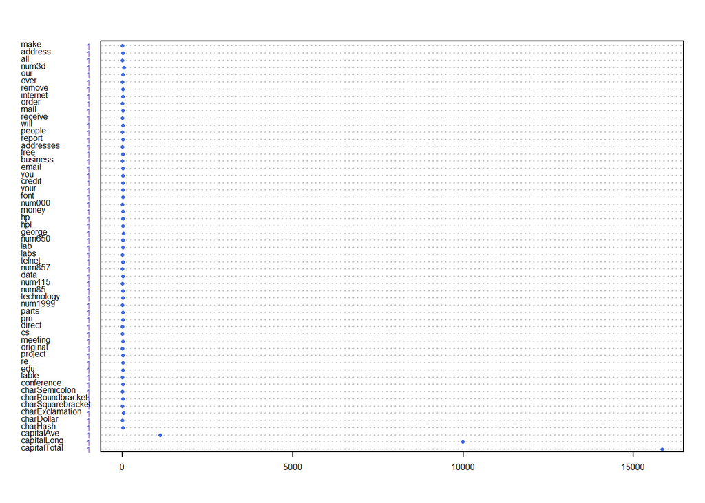

```r
spam %>%
  select(-58) %>%
  summarise_all(funs(max(.)-min(.))) %>%
  as.matrix() %>%
  dotchart(cex=0.5, pch = 16, col = "royalblue")
```

Wizualizacja bez zmiennych informujących o długości ciągów znaków:

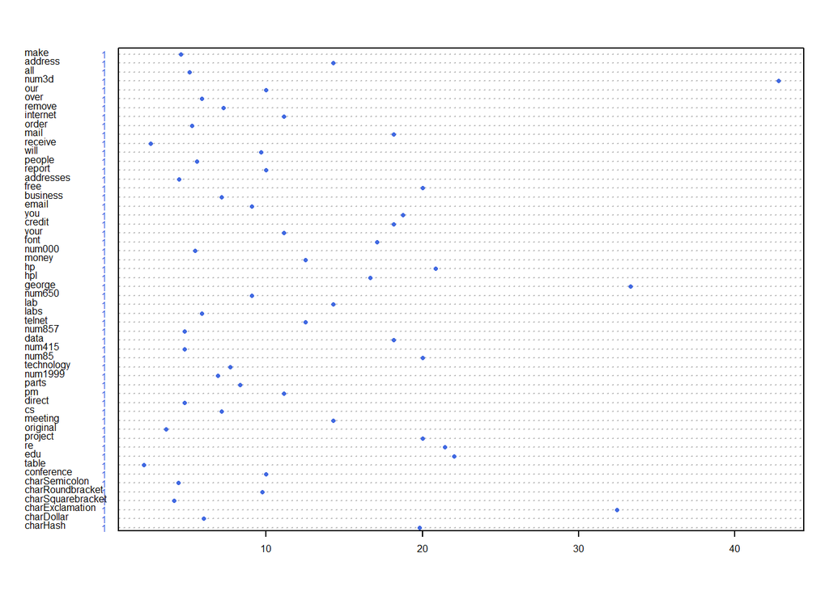

```r
spam %>%
  select(-c(55:58)) %>%
  summarise_all(funs(max(.)-min(.))) %>%
  as.matrix() %>%
  dotchart(cex=0.5, pch = 16, col = "royalblue")
```

#### Normalizacja

Najczęściej stosowaną normalizacją jest normalizacja *min-max*:

$$x_{i, norm} = \frac{x_{i} - x_{min}}{x_{max} - x_{min}}$$

Normalizacja każdej zmiennej z wyłączeniem atrybutu decyzyjnego:

```r
normalizuj <- function(x){
  (x-min(x))/(max(x)-min(x))
}

spam_norm <- spam %>%
  select(-type) %>%
  mutate_all(funs(normalizuj(.)))
```

Wizualizacja rozpiętości wartości wag dla każdej zmiennej po normalizacji (bez atrybutu decyzyjnego):

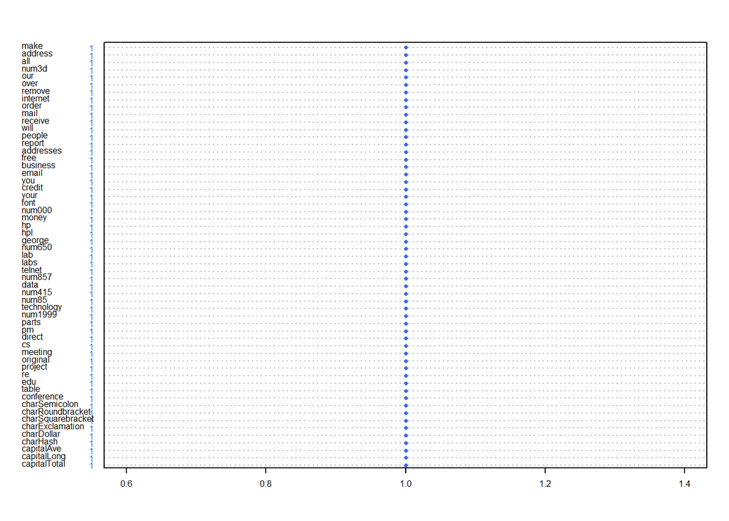

```r
spam_norm %>%
  summarise_all(funs(max(.)-min(.))) %>%
  as.matrix() %>%
  dotchart(cex=0.5, pch = 16, col = "royalblue")
```

#### Utworzenie zbioru wejściowego

Do tabeli wartości znormalizowanych należy dołączyć kolumnę z atrybutem decyzyjnym.

```r
spam_norm <-  spam_norm %>%
  bind_cols(Klasa = spam$type)
```

### Analiza właściwa

1. Podział zbioru danych na zbiór uczący i testowy
2. Zastosowanie algorytmu *`k-nn`* - dla `k = {1, 3, 7}`
3. Porównanie wyników - ocena trafności klasyfikacji

```
## [1] "Trafność klasyfikatora k-nn, przy k = 1 wynosi: 0.886149383611313"
```

```
## [1] "Trafność klasyfikatora k-nn, przy k = 3 wynosi: 0.886874546773024"
```

```
## [1] "Trafność klasyfikatora k-nn, przy k = 7 wynosi: 0.886149383611313"
```

## Zadanie 2.

Korzystając ze zbioru danych **`spam{kernlab}`** przygotuj klasyfikator z wykorzystaniem algorytmu `naiveBayes`, dla całego zbioru danych.

1. Podział zbioru danych na zbiór uczący i testowy
2. Zastosowanie algorytmu *`naiveBayes`*
3. Ocena trafności klasyfikacji

```
## [1] 0.7186367
```